# East Troublesome Fire Effect on the Watershed

Madison Thompson

5/12/2022

# Introduction

When wildfires occur, it creates major damages through the entire land and ecosystem of the area. A large part of the ecosystem that is affected is the watershed of the area. When a wildfire burns through the area it creates long-term affects that can alter the streamflow and water quality of that watershed. These wildfires were once a common natural occurrence in most forest ecosystems that did not have a devastating effect on the land. But in more recent years things such as climate change, fuel load accumulation, extensive droughts, and an increase in human presence in forests has caused a devastating effect on the land when these wildfires burn. The concern that comes from these factors has put a heavier strain on the understanding on how the landscape changes and reacts to the wildfire. There is a need to understand the interaction between wildfire, and associated responses in vegetation cover, and hydrologic and geomorphic behavior. [@owens_muted_2013]

When a wildfire burns it way through the land it often causes dramatic changes in forest vegetation structure and soil conditions, it also alters the watershed processes that control streamflow, soil erosion, nutrient export, and downstream water chemistry [@hohner_wildfires_2019]. The effect of erosion, infiltration, runoff, and slope failure play a major role in how the land is re-molded. These changes can include the streamflow, landscape, and the soil of the land. When a forest is undisturbed its soils have relatively high infiltration rates that helps to control runoff effects. Wildfires can reduce infiltration by exposing mineral soil to rain drop impact and splash that can seal soil pores at the surface [@ice_effects_nodate]. The effect that comes from the wildfire then causes dramatic changes in both annual and peak streamflows. The wildfires remove features from the land that shows decreased infiltration rates and increased runoff rates. As seen with high-severity fires heat the mineral soil and consume all vegetative ground cover, leaving only ash at the soil surface [@kunze_streamflow_2006]. With the features burned away from the land it decreases infiltration and increases runoff creating a negative effect to streamflow and water quality. Reduced infiltration then promotes overland flow, surface erosion, runoff, and sediment that contributes to debris and extreme channel impacts that affect streamflow. These effects from a wildfire creates a domino effect that starts with the forest ecosystem and begins to alter the land and watershed from the most obvious to the least observed occurrences.

After the wildfire causes changes to the watersheds soil and hydrologic system it then leads to further effects on the land and water quality. Sediment load, flooding, runoff, and erosion create new factors to consider. These large erosion events, such as those caused by wildfire, are short-lived on geological time scales, but can dominate the long-term sediment yield response[@murphy_effects_nodate]. This is an important factor to consider because of the water quality of the watershed. The mineralization of organic matter, interruption of root uptake, and loss of shade can further impact water quality by increasing stream temperatures and nutrient concentrations [@ice_effects_nodate]. Most water quality issues that occur in each watershed is seen after the wildfire is out. The postfire effects that is seen on the water quality has to do with water surface composition and the drinking water treatment. Once down-stream the water quality effects is better seen at water treatment plants and what needs to be done now to purify the water that was affected by postfire conditions. Extreme postfire erosion can damage infrastructure, accumulate in reservoirs, and challenge coagulation, filtration, and solids handling processes [@hohner_wildfires_2019]. With all these factors occurring it causes these water treatment facilities to adapt to these new quality features so that the people dependent on that water source can still use the water source. Changes in the quantity and composition of dissolved organic matter (DOM) exported from burned watersheds can influence treatment process performance and the formation of disinfection byproducts (DBPs) [@hohner_wildfires_2019]. This is important to understand to see the effects the wildfire has on the water quality. Here it is seen that even after the fire is out it does not mean the effects of the fire is gone.

In the state of Colorado warmer spring air temperatures and longer wildfire seasons in the western US [@mast_water-quality_2016] had created the land for larger and longer wildfire season. This increase has created concern for larger fires to appear across Colorado’s Front Range. With the possibility of even larger fires to occur it creates instability in the land once the fire burn through it, which creates alterations to the watersheds associated with the fire. Postfire the largest change in the land is the increase in runoff and erosion. The effects that come from runoff and erosion has pushed for efforts to better understand wildfires in the Colorado Front Range and effects it has on the soil and water quality. An example of a wildfire that has affected a watershed was that of the East Troublesome Fire that occurred the afternoon of October 14, 2020. Fire behavior played a large role in the severity of impacts to soil in the East Troublesome fire [@us_national_forest_east_2020]. The fire also altered the watershed of this area due to the location of this wildfire. The fire burned at a high elevation which is composed of a dominated snowmelt watershed attached to the Upper Colorado River. The watershed response within the burned area will likely include an initial flush of ash, rill, and gully erosion in headwater drainages and on steep slopes, areas with snowmelt peak flows elevated over 50% relative to pre-fire, sediment-laden flash floods following high-intensity rain events, and potentially debris flows [@us_national_forest_east_2020]. This effect on the watershed can affect the soil, land, and water quality. The streamflow is also highly affected by such a fire due to the debris that fall into the streams. Debris flows are among the most hazardous consequences of rainfall on burned hillslopes [@us_national_forest_east_2020]. These kinds of debris can affect the streamflow and effect the watershed overall. This study will be looking more into the East Troublesome Fire and the effects, it has had on the streamflow and water quality of the watershed.

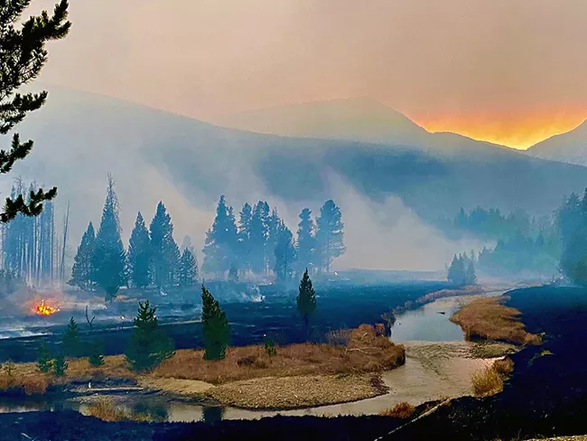

East Troublesome Fire in the Kawuneechee Valley. NPS, C. Kopek

# Abstract

[output not shown]

# Methods

## USGS Sites

```r
site_no <- "09034250"
site_no2 <- "09040500"
site_no3 <- "09014050"

control_site <- "09027100"
```

Site Numbers labeld to help pull data for each considered site.

## Downloaded Discharge Data

```r
# Discharge data pulled form the site_no from 10/01/1986 to 1/1/2022
q <- readNWISdv(siteNumbers = site_no,
                parameterCd = '00060',
                startDate = '1986-10-01',
                endDate = '2022-01-01') %>%
  rename(q_cfs = X_00060_00003) %>%
  addWaterYear(.) %>%
  select(-agency_cd, -X_00060_00003_cd)

q_ind <- q %>%
  mutate(q_in = (((q_cfs / (2.311*10^10))*3600)*12)*24 )

# site_no2
q2 <- readNWISdv(siteNumbers = site_no2,
                parameterCd = '00060',
                startDate = '1986-10-01',
                endDate = '2022-01-01') %>%
  rename(q_cfs = X_00060_00003) %>%
  addWaterYear(.) %>%
  select(-agency_cd, -X_00060_00003_cd)

q2_ind <- q2 %>%
  mutate(q_in = (((q_cfs / (4.684*10^9))*3600)*12)*24 )

# site_no3
q3 <- readNWISdv(siteNumbers = site_no3,
                parameterCd = '00060',
                startDate = '1986-10-01',
                endDate = '2022-01-01') %>%
  rename(q_cfs = X_00060_00003) %>%
  addWaterYear(.) %>%
  select(-agency_cd, -X_00060_00003_cd)

q3_ind <- q3 %>%
  mutate(q_in = (((q_cfs / (2.311*10^10))*3600)*12)*24 )

# control site
qC <- readNWISdv(siteNumbers = control_site,
                parameterCd = '00060',
                startDate = '1986-10-01',
                endDate = '2022-01-01') %>%
  rename(q_cfs = X_00060_00003) %>%
  addWaterYear(.) %>%
  select(-agency_cd, -X_00060_00003_cd)

qC_ind <- qC %>%
  mutate(q_in = (((q_cfs / (3.206*10^9))*3600)*12)*24 )
```

Code used to dowload dischrage from each site in cfs then covnverted in in/d.

## Turbidity

```r
# site 1 daily turbidity
T1_l <- readNWISuv(siteNumbers = site_no,
                parameterCd = '63680')%>%
  mutate(dateTime = lubridate::as_datetime(dateTime),
         date = lubridate::as_date(dateTime))%>%
  group_by(site_no, date)%>%
  summarize(mean = mean(X_63680_00000))

write_csv(T1_l,'data/T1maddy.csv')

Turbidity_1 <- read_csv('data/T1maddy.csv')%>%
  rename( Date = date)

# compressed dated data
T1_s <- with(T1_l, T1_l[(date >= "2021-06-07" & date <= "2021-10-01"), ])

write_csv(T1_s,'data/T1smaddy.csv')

Turbidity_1s <- read_csv('data/T1smaddy.csv')%>%
  rename( Date = date)

# site 2 daily turbidity
T2_l <- readNWISuv(siteNumbers = site_no2,
                parameterCd = '63680')%>%
  mutate(dateTime = lubridate::as_datetime(dateTime),
         date = lubridate::as_date(dateTime))%>%
  group_by(site_no, date)%>%
  summarize(mean = mean(X_63680_00000))

write_csv(T2_l,'data/T2maddy.csv')

Turbidity_2 <- read_csv('data/T2maddy.csv')%>%
  rename( Date = date)

# compressed dated data
T2_s <- with(T2_l, T2_l[(date >= "2021-06-07" & date <= "2021-10-01"), ])

write_csv(T2_s,'data/T2smaddy.csv')

Turbidity_2s <- read_csv('data/T2smaddy.csv')%>%
  rename( Date = date)

# site 3 daily turbidity

# longer dated data
T3_l <- readNWISuv(siteNumbers = site_no3,
                parameterCd = '63680')%>%
  mutate(dateTime = lubridate::as_datetime(dateTime),
         date = lubridate::as_date(dateTime))%>%
  group_by(site_no, date)%>%
  summarize(mean = mean(X_63680_00000))


write_csv(T3_l,'data/T3lmaddy.csv')

Turbidity_3l <- read_csv('data/T3lmaddy.csv')%>%
  rename( Date = date)

# compressed dated data
T3_s <- with(T3_l, T3_l[(date >= "2021-06-07" & date <= "2021-10-01"), ])

write_csv(T3_s,'data/T3smaddy.csv')

Turbidity_3s <- read_csv('data/T3smaddy.csv')%>%
  rename( Date = date)


# control site daily turbidity
TC_l <- readNWISuv(siteNumbers = control_site,
                parameterCd = '63680')%>%
  mutate(dateTime = lubridate::as_datetime(dateTime),
         date = lubridate::as_date(dateTime))%>%
  group_by(site_no, date)%>%
  summarize(mean = mean(X_63680_00000))


write_csv(TC_l,'data/TCmaddy.csv')

Turbidity_C <- read_csv('data/TCmaddy.csv')%>%
  rename( Date = date)

# compressed dated data
TC_s <- with(TC_l, TC_l[(date >= "2021-06-07" & date <= "2021-10-01"), ])

write_csv(TC_s,'data/TCsmaddy.csv')

Turbidity_Cs <- read_csv('data/TCsmaddy.csv')%>%
  rename( Date = date)
```

Code downloaded continuous turbidity data, where it then converts the continuous data into daily data. After this code runs I then create a csv file of the daily data and then recall it to my data source. I aslo had to shorten collected dates on certain turbidity levels for combined figure 3.9 to show values during the same time after the fire.

## Combined Data

### Discharge

```r
Q_c <- rbind(q_ind, q2_ind, qC_ind)

Q_cr <-Q_c

Q_cr$site_no <- fct_recode(Q_cr$site_no ,
                                 "Low Burn " = "09034250",
                                 "High Burn" = "09040500",
                                 "No Burn" = "09027100")

colnames(Q_cr)[1] <- "BurnLevel"
```

Code binds all needed data sets and then re codes the site_no column to rename the site numbers to burn level, and then I renamed the column name to BurnLevel.

### Turbidity

```r
T_c <- rbind(Turbidity_1s, Turbidity_2s, Turbidity_3s, Turbidity_Cs)

T_cr <- T_c

T_cr$site_no <- fct_recode(T_cr$site_no ,
                                 "Low Burn 1" = "09014050",
                                 "Low Burn 2" = "09034250",
                                 "High Burn" = "09040500",
                                 "No Burn" = "09027100")

colnames(T_cr)[1] <- "BurnLevel"
```

Code binds all needed data sets and then re codes the site_no column to rename the site numbers to burn level, and then I renamed the column name to BurnLevel.

## Site Discription

[Low Burn: USGS 09014050 GRAND LAKE OUTLET BLW CHIPMUNK LN AT GRAND LK, CO] [Low Burn: USGS site 09034250 COLORADO RIVER AT WINDY GAP, NEAR GRANBY, CO.] [High Burn: USGS 09040500 TROUBLESOME CREEK NEAR TROUBLESOME, CO.] [Not Burned: USGS 09027100 FRASER RIVER AT TABERNASH, CO]

### Deliniated Watershed

```r
watershed <- st_read('Granby.geojson')%>%
  dplyr::filter(id=='globalwatershed')
```

```r
mapview(watershed)
```

[interactive chart not shown]

Watershed of the sites 09014050 located at Grand Lake Outlet and 09034250 located at the Colorado River at Windy Gap. Both site are considered a low burn gauge.

```r
watershed_2 <- st_read('Troublesome.geojson')%>%
  dplyr::filter(id=='globalwatershed')
```

```r
mapview(watershed_2)
```

[interactive chart not shown]

Watershed of site 09040500 located at Troublesome creek. This site is considered a high burn gauge.

```r
watershed_c <- st_read('NewControl.geojson')%>%
  dplyr::filter(id=='globalwatershed')
```

```r
mapview(watershed_c)
```

[interactive chart not shown]

Watershed of site 09027100 located at Fraser River. This site is considered a non burned gauge and is the control site.

# Results

## Discharge Data

[figure not shown]

Discharge (in/day) recorded from 1986-10-01 to 2022-01-01. Site is low burned and located near Grandby, CO.

```r
# Plot for discharge
{ q1 = "Discharge (in/day) recorded from 1986-10-01 to 2022-01-01. Site is low burned and located near Grandby, CO."}

ggplot(q_ind, aes(x = Date, y = q_in))+
  geom_line()+
  labs( title = 'Discharge at Colorado River Gauge',
        subtitle = 'USGS site 09034350',
        x = 'Year',
        y = 'Q (in/day)' )
```

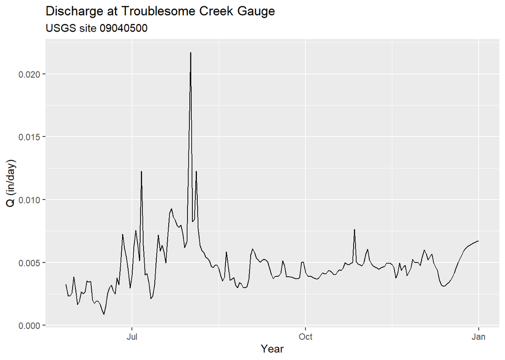

```r
# site_no2
ggplot(q2_ind, aes(x = Date, y = q_in))+
  geom_line()+
  labs( title = 'Discharge at Troublesome Creek Gauge',
        subtitle = 'USGS site 09040500',
        x = 'Year',
        y = 'Q (in/day)')
```

Figure 3.2 represents Discharge (Q) levels measured at the USGS site 09040500 located at Troublesome Creek,near Grandby, CO. Due to the location of of the fire this site is considered a high burn area. Data was only collected The data collected here was for only on year after the fire occurred and showed overall low discharge values.

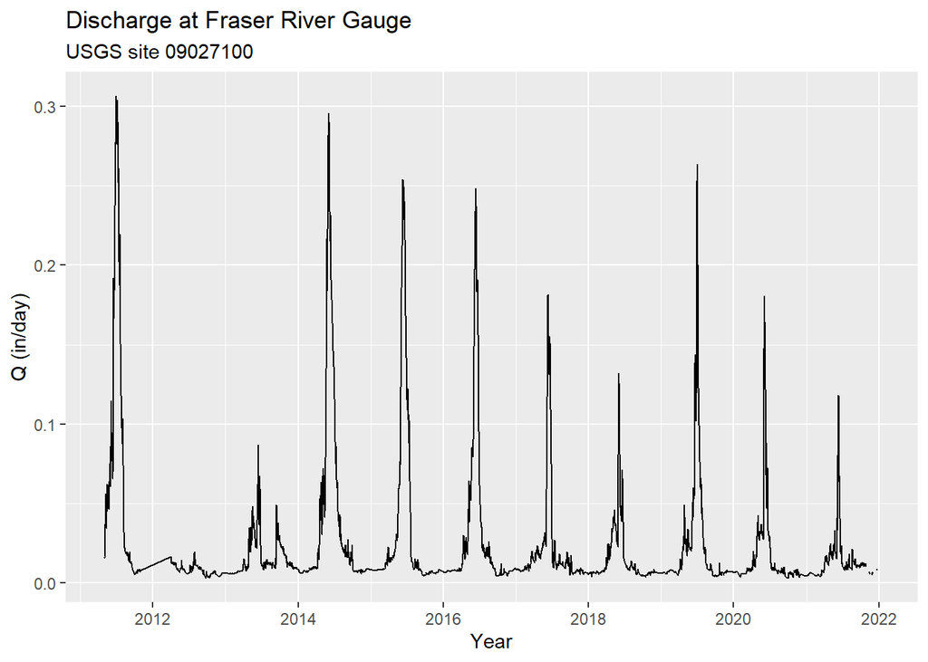

Discharge (in/day) recorded from 2011-05-01 to 2022-01-01. Site is in a non burned area and is the control site.

```r
# control site
ggplot(qC_ind, aes(x = Date, y = q_in))+
  geom_line()+
  labs( title = 'Discharge at Fraser River Gauge',
        subtitle = 'USGS site 09027100',
        x = 'Year',
        y = 'Q (in/day)')
```

Figure 3.3 represents Discharge (Q) levels measured at the USGS site 09027100 located at Fraser River near Tabernash, CO. This site was chosen as the control site since it was located away from the fire so the discharge rate were more consistent and had higher discharge rates

## Turbidity

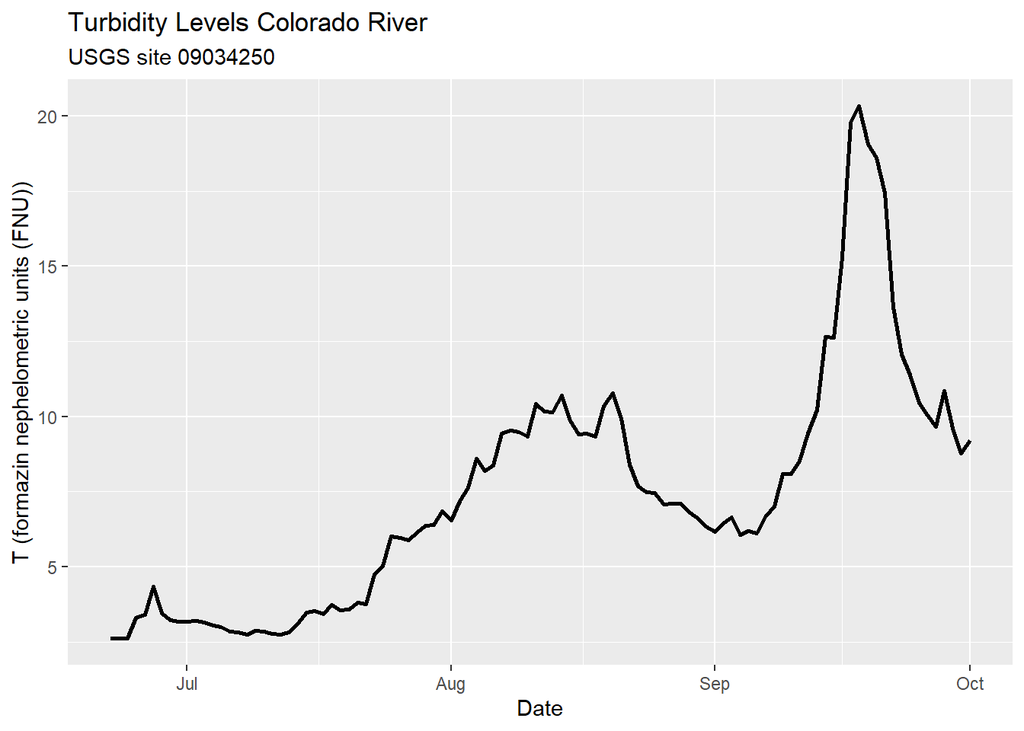

Turbidity data from USGS site 09034250 COLORADO RIVER AT WINDY GAP, NEAR GRANBY, CO. Reccorded time 2021-06-22 to 2021-10-01. USGS gauge located in low burn area

```r
# site 1
ggplot(Turbidity_1s, aes(x = Date, y = mean)) +
  geom_line(size = 1) +
  labs(title = 'Turbidity Levels Colorado River',
       subtitle = 'USGS site 09034250',
       x = 'Date',
       y = 'T (formazin nephelometric units (FNU))')
```

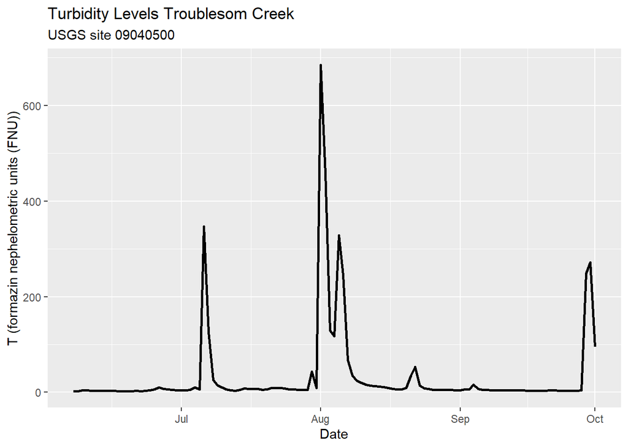

Turbidity data from USGS site 09040500 TROUBLESOME CREEK NEAR TROUBLESOME, CO. Reccorded time 2021-06-07 to 2021-10-01. USGS gauge located in high burn area.

```r
# site 2
ggplot(Turbidity_2s, aes(x = Date, y = mean)) +
  geom_line(size = 1) +
  labs(title = 'Turbidity Levels Troublesom Creek',
       subtitle = 'USGS site 09040500',
       x = 'Date',
       y = 'T (formazin nephelometric units (FNU))')
```

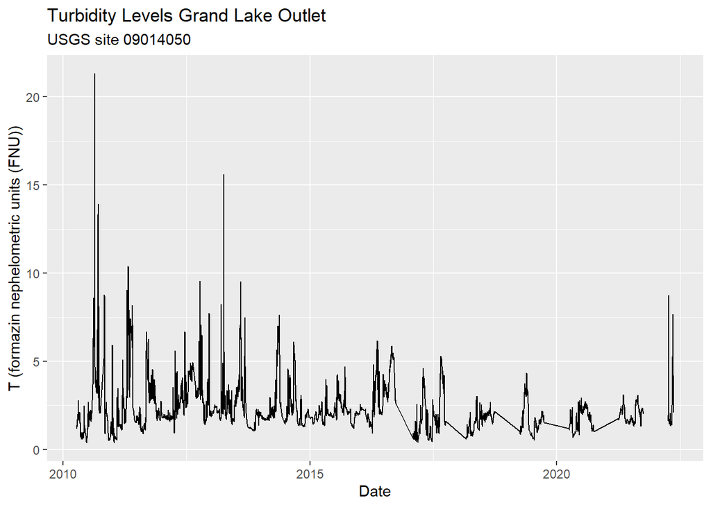

```r
# site 3
ggplot(Turbidity_3l, aes(x = Date, y = mean)) +
  geom_line(size = 0.5) +
  labs(title = 'Turbidity Levels Grand Lake Outlet',
       subtitle = 'USGS site 09014050',
       x = 'Date',
       y = 'T (formazin nephelometric units (FNU))')
```

[figure not shown]

```r
#control site
ggplot(Turbidity_Cs, aes(x = Date, y = mean)) +
  geom_line(size = 1) +
  labs(title = 'Turbidity Levels Fraser River',
       subtitle = 'USGS site 09070500',
       x = 'Date',
       y = 'T (formazin nephelometric units (FNU))')
```

Figure 3.7 represents Turbidity levels measured in formazin nephelometric units (FNU) measured at the USGS site 09027100 located at Fraser River near Tabernash, CO. This site was chosen as the control site since it was located away from the fire and had constant lower turbidity levels with only one major spike in August.

## Combined Data

#### Discharge

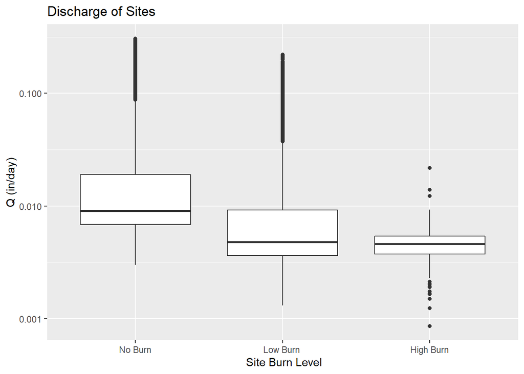

Discharge (in/day) from Troublesome Creek (high burn), Colorado River (low burn), and Fraser River (no burn)

```r
ggplot(Q_cr, aes(x= BurnLevel, y= q_in))+
  geom_boxplot()+
  scale_y_log10()+
  labs( title = 'Discharge of Sites',
        x = ' Site Burn Level',
        y = 'Q (in/day)')
```

Figure 3.8 represents a combined showing of all three sites discharge levels in box plot form to better show the distribution between the three sites. As seen in the figure discharge values decrease as the severity of the burned fire are increases.

### Turbidity

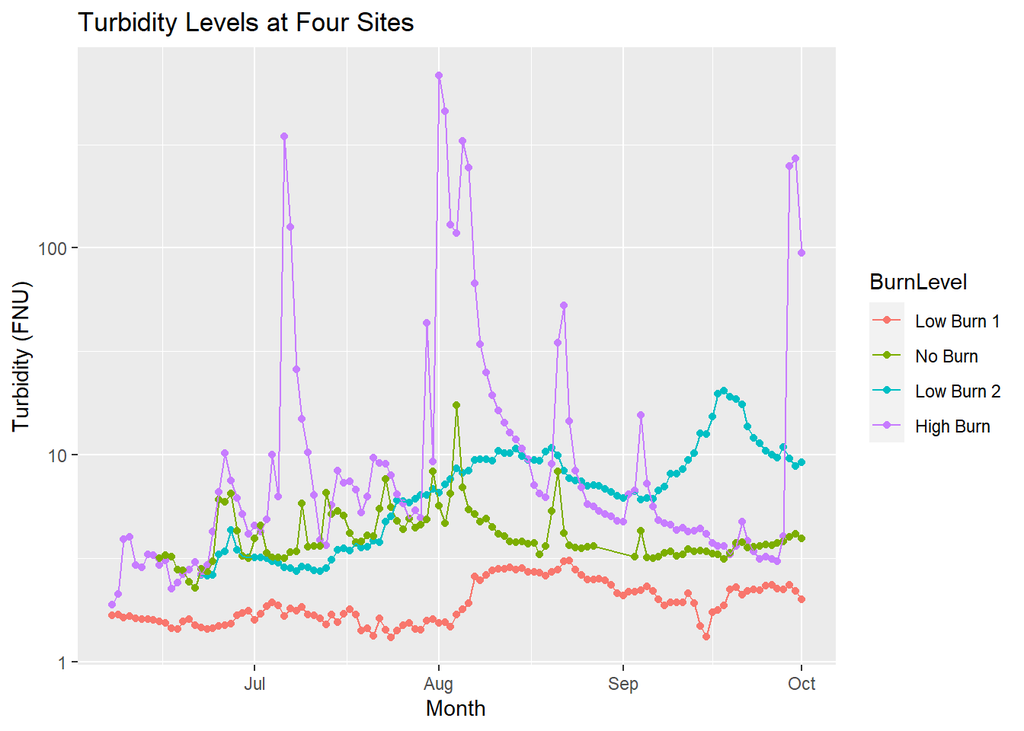

Turbidity levels from Troublesome Creek (high burn), Colorado River (low burn 2), Grand lake Outlet (low burn 1) and Fraser River (no burn

```r
ggplot(T_cr, aes(x= Date, y= mean, color = BurnLevel ))+
  geom_point()+
  geom_line()+
  scale_y_log10()+
  labs(title = "Turbidity Levels at Four Sites",
       x = "Month",
       y = "Turbidity (FNU)")
```

Figure 3.9 represents the combined turbidity values from June to October in the year 2021. As seen in the graph high burn severity has a high influence in increased turbidity, while low burn sites are not as greatly infulenced when comparing to the control site variable.

# Discussion

For the four sites I only used the Grand Lake site for turbidity data and not discharge due to the negative readings. Due to the location of the Grand Lake site the discharge levels at times were reading negatively which is not possible so I chose to not use the discharge data so that it does not affect my observation of the discharge data. The turbidity data was still reliable and that is why I only used that variable from this site when comparing values for my observations. That is why it is seen in Figure 3.8 there is only three sites and why in Figure 3.9 there is four sites.

[figure not shown]

https://data.rgj.com/fires/incident/photograph/7267/0/111385/

Observing Figure 3.9 shows the rate of turbidity for all four sites from June to October in the year 2021, the year after the fire occurred. Turbidity in streams will be better seen after the fire is out during snow melt and heavy rainfall as well. Since the fire occurred in late fall of 2020 turbidity would not be seen as well until the spring and summer time the following year, which is what Figure 3.9 represents. As seen in the figure the high burn level from Troublesome Creek which is marked as purple produced high turbidity levels and many increased spikes through the wetter seasons for Colorado. The periods of no precipitation, including snow melt, shows the low turbidity concentration. Then when precipitation rates occur turbidity results increased to greater rates due to the area being burned. These high turbidity rate from the high burned area is explained by the lack of infiltration and increase of runoff due to the vegetation being burned away. Then focusing on the other three sites presents how low burn areas and a control site can relate to each other. As seen in Figure 3.9 where the control site is colored green , the turbidity is much lower than the high burn area while it is similar to the low burn area. It is seen that the low burn area does not have a strong effect on turbidity levels as seen by both low burn areas. Where low burn 1 has turbidity levels lower than the control site and low burn 2 had turbidity levels that is not varied far from the values of the control site. The reason the low burn areas may not present high turbidity levels is due to the low burn on vegetation and the soil in the low burned gauges watershed. With less burn on the soil and vegetation infiltration is not as highly effected. With the possibility of the infiltration not being heavily effected during precipitation events the water is able to be better absorbed before reaching a stream system. Which then creates less runoff of sedimentation into the streams that then create lower turbidity levels. When a wildfire occurs it is seen in Figure 3.9 that primarily high burned areas will create detrimental and greater values of turbidity to the watershed effected. Overall it is seen that turbidity levels become worse the worse the land was burned. Another thing to consider is turbidity levels can remain at a high rate years after the fire occurred since it takes time for the land to heal.